# Distributed filesystems

Georgios Gousios and Burcu Kulahcioglu Ozkan

02 October 2023

# Distributed filesystems

## What is a filesystem?

File systems determine how data is stored and retrieved. A file system keeps track of the following data items:

- **Files**, where the data we want to store are.
- **Directories**, which group files together
- **Metadata**, such as file length, permissions and file types

The primary job of the filesystem is to make sure that the data is always accessible and intact. To maintain consistency, most modern filesystems use a *log* (remember databases!).

Common filesystems are EXT4, NTFS, APFS and ZFS

## Distributed file systems

A distributed filesystem is a file system which is shared by being simultaneously mounted on multiple servers. Data in a distributed file system is *partitioned* and *replicated* across the network. Reads and writes can occur on any node.

**Q:** Windows and MacOSX already have network filesystems. Why do we need extra ones?

. . .

Network file systems, such as CIFS and NFS, are not distributed filesystems, because they rely on a centralized server to maintain consistency. The server becomes a SPOF and a performance bottleneck.

## Big data revolution and large-scale file-system organization

Need for large, distributed, highly fault tolerant file system to store and process the queries.

Seminal papers:

- “*The Google file system.*” By Sanjay Ghemawat, Howard Gobioff, and Shun-Tak Leung (2003)
- “*MapReduce: Simplified data processing on large clusters.*” By Jeffrey Dean and Sanjay Ghemawat (2004)
- “*The Hadoop distributed file system*” by Konstantin Shvachko, Hairong Kuang, Sanjay Radia, and Robert Chansler (2010)

## The Google filesystem

The Google Filesystem paper[1] kicked-off the Big Data revolution. Why did they need it though?

- Hardware failures are common (commodity hardware)
- Files are large (GB/TB) and their number is limited (millions, not billions)
- Two main types of reads: large streaming reads and small random reads
- Workloads with sequential writes that append data to files
- Once written, the files are seldom modified, they are read often sequentially
- High sustained bandwidth trumps low latency

## Large-scale distributed file systems:

- Google File System (GFS)
- Hadoop Distributed File System (HDFS)
- CloudStore
- Amazon Simple Storage Service (Amazon S3)

## GFS architecture

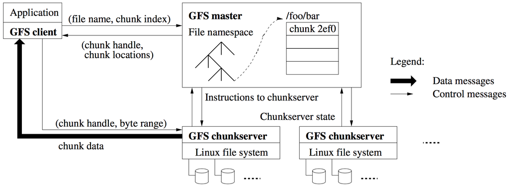

GFS Architecture

## GFS storage model

- A single file can contain many objects (e.g. Web documents)
- *Files* are divided into fixed size chunks (64MB) with unique identifiers, generated at insertion time.
  - Disk seek time small compared to transfer time
  - A single file can be larger than a node’s disk space
  - Fixed size makes allocation computations easy
- Files are replicated ($\ge 3$) across chunk servers.
- The *master* maintains all file system metadata (e.g. mapping between file names and chunk locations)
- *Chunkservers* store chunks on local disk as Linux files
  - Reading & writing of data specified by the tuple `(chunk_handle, byte_range)`
- Neither the client nor the chunkserver cache *file data* (Why?)

## GFS reads

- Client sends file read request to GFS master
- Master replies with chunk handle and locations
- Client caches the metadata
- Client sends a data request to one of the replicas
- The corresponding chunk server returns the requested data

## GFS writes

- The client sends a request to the master server to allocate the primary replica chunkserver
- The master sends to the client the location of the chunkserver replicas and the primary replica
- The client sends the write data to all the replicas chunk server’s buffer
- Once the replicas receive the data, the client tells the primary replica to begin the write function (Primary assigns serial number to write requests)
- The primary replica writes the data to the appropriate chunk and then the same is done on the secondary replicas
- The secondary replicas complete the write function and reports back to the primary
- The primary sends the confirmation to the client

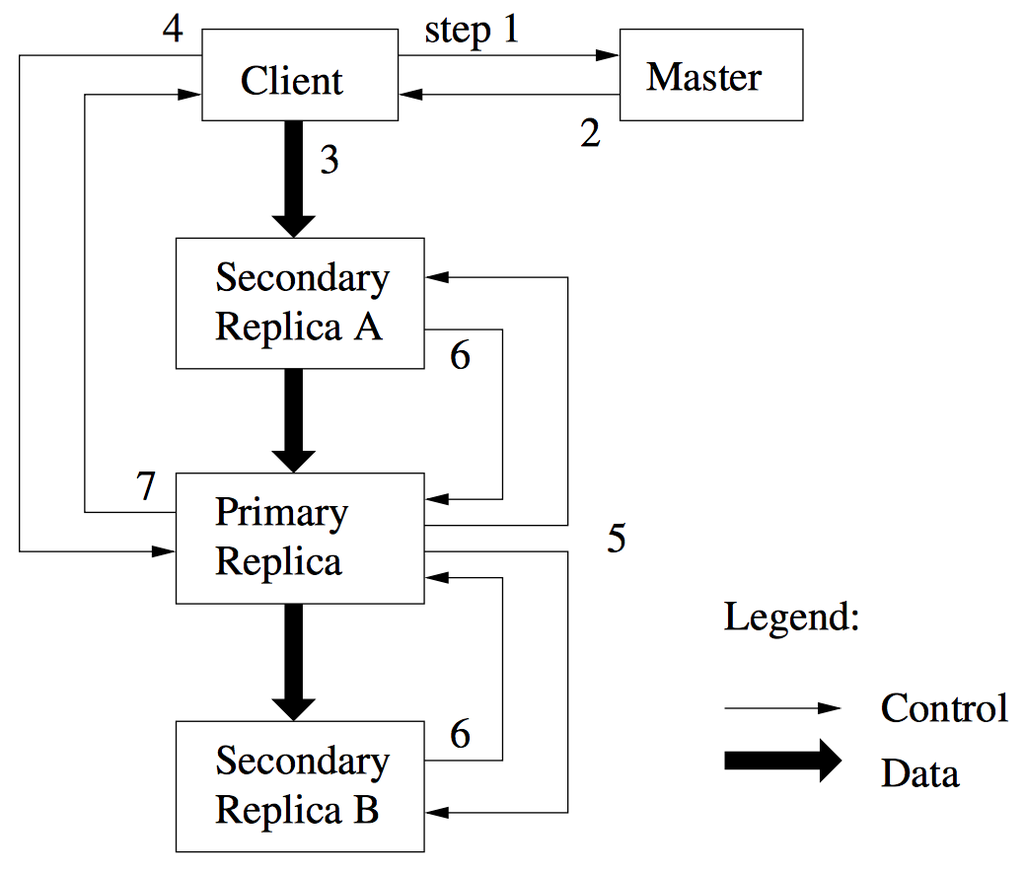

Writes on a GFS filesystem

## GFS operation

- The master does not keep a persistent record of chunk locations, but instead queries the chunk servers at startup and then is updated by periodic polling.
- GFS is a *journaled* filesystem: all operations are added to a log first, then applied. Periodically, log compaction creates checkpoints. The log is replicated across nodes.
- If a node fails:
  - If it is a master, external instrumentation is required to start it somewhere else, by rerunning the operation log
  - If it is a chunkserver, it just restarts
- Chunkservers use checksums to detect data corruption
- The master maintains a chunk version number to distinguish between up-to-date and stale replicas (which missed some mutations while its chunkserver was down
  - Before an operation on a chunk, master ensures that version number is advanced